# Quantitative Genetics

Components of Total Genetic Variance

Felipe Ferrão

University of Florida – 2024

**Objectives:**

- 15 minutes of hands-on
- Introduction to genomic variance and heritability

**Extra information**

- [PCB 6555 – Website](https://lfelipe-ferrao.github.io/class/quantGenetic/)
- About the [author](https://lfelipe-ferrao.github.io/)
- About the [UF/IFAS Plant Breeding](https://programs.ifas.ufl.edu/plant-breeding/)

# Introduction

We discussed along this course that the genetic description of a quantitative trait should be primarily investigated at the population level, in the form of **mean** and **variance**. The next step in to understand the variability. Herein, we will report it in the form of genetic and environmental components, where the genotypic value can be decomposed into additive and dominance components.

# Theory

## Variance

The genetic basis of a quantitative trait is grounded on its variation ! When talking to any breeder, its is common to discuss about genetic variability in a given population. This is part of the main vocabulary of breeders, because it will determine the genetic gains in a breeding program.

To measure this variation, we first need to represent the phenotypic variance in terms of variance and, more importantly, divide it into components associated to additive and non-additive sources.

To this end, let’s start with some basic statistical concepts:

$$\begin{align*}
\sigma^2 = \dfrac{\sum(X-\mu)^2}{N}
= \dfrac{\sum(X^2- 2\mu X + \mu ^2)}{N}\\
= \dfrac{\sum X^2}{N} - 2\mu \dfrac{\sum X^2}{N} + \dfrac{\sum
\mu^2}{N}\\
= \dfrac{\sum X^2}{N} - 2 \mu^2 + \mu^2\\
= \dfrac{1}{N} \sum X^2 - \mu^2
\end{align*}$$

Based on this expression, we can simply think on the variation equation expressed as: $freq \times value^2 - mean^2$; this can make some of our calculations easier in this document.

## Components of Variance

In the last classes we devoted considerable effort to developing expressions for average values.

In particular, we obtained expressions for the breeding value and dominance deviation of each genotype. Obtaining these averages was important because an average is a critical part of a variance. Given the properties of variance, assuming that G= A+D, the variance of G is given by $V_G = V_A + V_D + 2COV_{AD}$. The covariance is equal to zero and therefore the $V_G = V_A + V_D$.

Similarly, we can assume HW equilibrium, and compute the genotypic variance using basic statistical principles, as follow:

$$\begin{align*}
\sigma_g^2 = \sum_i f_i X_i^2 - \left( \dfrac{\sum_i f_i X_i}{\sum
f_i} \right)^2 \\
= p^2(a^2) + 2pq(d^2) + q^2(-a)^2 - [a(p-q) + 2pqd]^2\\
= a^2(p^2+q^2) + 2pq(d^2) - a^2(p-q)^2 - 2a(p-q)(2pqd) - (2pqd)^2\\
= a^2(2pq) + 2pq(d^2-2apd+2aqd-2pqd^2) \\
= 2pq[a^2+d^2+2ad(q-p)-2pqd^2]\\
= 2pq[a^2+d^2(1-2pq)+2ad(q-p)]\\
= 2pq[a^2+d^2(p^2+2pq+q^2-2pq)+2ad(q-p)]\\
= 2pq[a^2+d^2(p^2-2pq+q^2)+2ad(q-p)]+(2pqd)^2\\
= 2pq[a^2 + d^2(p^2-2pq+q^2) + 2ad(q-p)] + (2pqd)^2\\
= 2pq[a^2 + d^2(q-p)^2 + 2ad(q-p)] + (2pqd)^2\\
= 2pq[a + d(q-p)]^2 + (2pqd)^2\\
\end{align*}$$

This expression can be written and expressed in different forms. Herein, we prepare the equation and deduction to express two terms: variance associated to the additive and dominance effects. In the sequence, we will present more details about each one.

### Additive Variance

The additive variance, or $V_A$ , is the variance of the additive effects (breeding values) in a randomly mating population. Since the mean breeding value taken over all genotypes is zero, the variance in breeding value is simply the square of the mean breeding value for each genotype multiplied by the frequency of each genotype:

$$\begin{align*}
V_A = p^2 (2q\alpha)^2 + 2pq[(q - p) \alpha ]^2 + q^2 (-2p\alpha )^2\\
= 4p^2 q^2 \alpha^2 + 2pq(q^2 - 2pq + p^2) \alpha^2 + 4p^2 q^2
\alpha^2\\
= 2pq \alpha^2 (2pq + q^2 - 2pq + p^2 + 2pq)\\
= 2pq\alpha^2 = 2pq[a + d(q - p)]^2
\end{align*}$$

### Dominance Variance

Similarly, the dominance variance, or V D , is the variance in dominance deviation values in a randomly mating population. As before, the mean dominance deviation taken over all genotypes is zero so the variance in breeding value is the square of the mean dominance deviation for each genotype multiplied by the frequency of each genotype:

$$\begin{align*}
V_D = p^2 (-2q^2 d)^2 + 2pq(2pqd)^2 + q^2 (-2p^2d)^22\\
= d^2 (4p^2 q^4 + 8p^3 q^3 + 4p^4 q^2 )\\
= 4p^2 q^2 d^2 (q^2 + 2pq + p^2 )\\
= (2pqd)^2
\end{align*}$$

Note that $2pq$, a common term in both expressions, is the expected heterozygosity or expected frequency of heterozygotes with Hardy–Weinberg equilibrium.

### Genotypic Variance

Genotypic Variance is commonly referred to as the total genetic variance, even though it is the variance in genotypic values and does not account for interactions between different loci in the genome. The decomposition of the genotypic value in the sum of its components implies that the additive and dominance values are independent, since it is an orthogonal partition, so the covariance between both components is zero.

$$\begin{align*}
V_G= V_A + V_D\\
= 2pq[a + d(q − p)]^2 + (2pqd)^2\\
\end{align*}$$

The relative magnitude of the additive and dominance variances depends on the type of gene action and the allele frequencies. In the sequence, we will present a simple graphical representation of the additive and dominance variance values, depending on the $\alpha$ values, dominance and allele frequency.

**Some R codes**

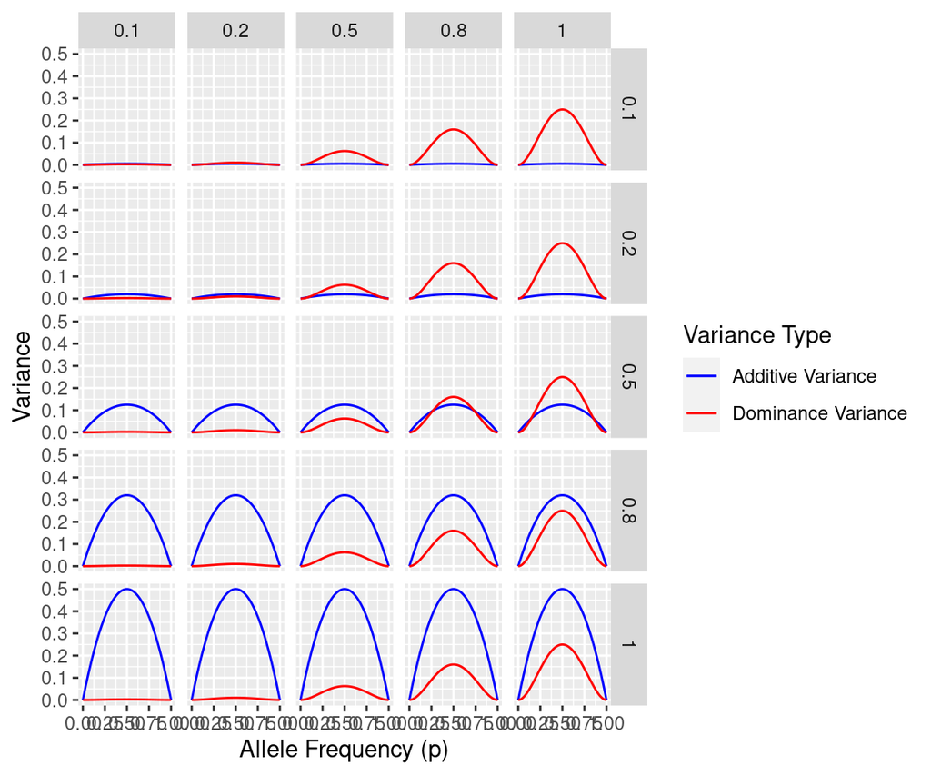

```r
# Load necessary library
library(ggplot2)

# Define allele frequencies
p <- seq(0, 1, by = 0.01)
q <- 1 - p

# Define alpha and d values to test
alpha_values <- c(0.1, 0.2, 0.5, 0.8, 1)
d_values <- c(0.1,0.2, 0.5,0.8, 1)

# Create an empty list to store data frames
list_of_dfs <- list()

# Loop over alpha values and d values to calculate variances and store in a list
for (alpha in alpha_values) {
  for (d in d_values) {
    additive_variance <- 2 * p * q * alpha^2
    dominance_variance <- (2 * d * p * q)^ 2

    df <- data.frame(
      AlleleFrequency = p,
      AdditiveVariance = additive_variance,
      DominanceVariance = dominance_variance,
      Alpha = as.factor(alpha),   # Include alpha value as a factor for faceting
      D = as.factor(d)            # Include d value as a factor for faceting
    )

    list_of_dfs[[paste(alpha, d, sep = "_")]] <- df
  }
}

# Combine all data frames into one
combined_df <- do.call(rbind, list_of_dfs)

# Create the plot
ggplot(combined_df, aes(x = AlleleFrequency)) +
  geom_line(aes(y = AdditiveVariance, color = "Additive Variance")) +
  geom_line(aes(y = DominanceVariance, color = "Dominance Variance")) +
  facet_grid(Alpha~ D) +
  labs(
    x = "Allele Frequency (p)",
    y = "Variance",
    color = "Variance Type"
  ) +
  scale_color_manual(values = c("Additive Variance" = "blue", "Dominance Variance" = "red"))
```

## Correlation and Interactions

In principle, we should present the phenotypic variance as $V_P= V_G+V_E+2COV_{GE}$.

We usually neglect the $COV$ in experimental populations, where randomization is a key principle in experimental design and hence break this covariance between genotypes and environments. However, genotype-environment interaction is a very important source of phenotypic variance and it will be considered in the future.

- Repeatability: when more than one measurement of the trait can be made on each individual, the phenotypic variance can be partitioned into variance within individual and between individual. This partition corresponding to the *repeatability* and is not part of genetic theory because is the environment and not the genetic portion that is replicated.

## Heritability

The heritability is used to express the proportion of the total phenotypic variance ($V_P$) that is caused by either all types of genotypic variance ($V_G$) or by only the additive genetic variance ($V_A$). The heritability is the most measured and discussed quantity in quantitative genetics, both in plant and animal breeding and also when applied to natural populations. It is so important because it partly determines how rapidly the mean phenotype evolves in response to artificial or natural selection.

There are two definitions of heritability. **Broad-sense heritability** is based on genotypic variance: $h^2 = \dfrac{V_G}{V_P}$; and measures the extent to which phenotypic variation is determined by genotypic variation. Broad-sense heritability includes the effects of dominance and epistatic variance and therefore is most useful in clonal or highly selfing species in which genotypes are passed from parents to offspring more or less intact; in these species it is the broad sense heritability that affects evolutionary rates. In outbreeding species evolutionary rates are affected by narrow-sense heritability, the proportion of total phenotypic variance that is determined by additive variance:$H^2 = \dfrac{V_A}{V_P}$.

It has long been observed that there is a correlation between the type of trait and the magnitude of its narrow-sense heritability. Life-history traits such as survival and number of progeny generally exhibit the lowest narrow-sense heritabilities whereas physiological, behavioral and morphological phenotypes show progressively greater narrow-sense heritabilities. One hypothesis is that traits more closely related to fitness are likely to be under stronger and more consistent natural selection pressures than arbitrary morphological phenotypes.

There are a large number of misconceptions relating to heritability, even among biologists, so it is important to stress the following points.

- There is not one heritability for a given trait in a given species, because heritability can and often does differ among populations and among environments.
- Since heritability is a proportion of variances, and the numerator is contained in the denominator, it is dimensionless and theoretically varies from zero to one, although with experimental error estimates of heritability can be outside these bounds.
- Another common misconception is that a heritability of zero means that the trait is not affected by genes. The reason this is not true is due to the effects of fixed loci (or absence of variability) in a given population.
- A final misconception is that a heritability of one means that the environment cannot affect a trait. A heritability of one means only that the environmental variation that was present in that particular population did not affect the phenotypic variance. If the environment changes, this could still change the mean and variance for the trait.

# Hands-on

## Breeding scenarios

### F2 population

If we consider a F2 population, in HW equilibrium, and same allele frequency (p=q=0.5). Using the mean and variance equations presented along the class, we have the following main parameters.

- $\mu_g = u + a(p-q) + 2pqd = u + a(1/2-1/2) + 2(1/2x1/2)d = u + 1/2d$
- $\alpha = a + d(q-p) = a + d(\frac{1}{2}-\frac{1}{2}) = a$
- $\sigma_{g}^{2} = 2pq\alpha^{2} + (2pqd)^{2} = 2x(\frac{1}{2})(\frac{1}{2})a^{2} + [2(\frac{1}{2})(\frac{1}{2})d]^{2} = \frac{1}{2}a^{2}+\frac{1}{4}d^{2}$

In particular, we can see that genetic variance will be a function of the allele frequency and dominance degree.

Let’s put it into the graphical form in R:

[figure not shown]

```r
# Define the function
var_g <- function(p, d, a) {
  alpha <- a + d * (1 - 2 * p)
  2 * p * (1 - p) * alpha^2 + (2 * d * p * (1 - p))^2
}

# Create a sequence for p
p <- seq(0, 1, 0.01)

# Create different dataframes for different d/a ratios
df_d_a_1 <- data.frame(p = p, var_g = var_g(p, 1, 1))
df_d_a_0 <- data.frame(p = p, var_g = var_g(p, 0, 1))
df_d_a_0.5 <- data.frame(p = p, var_g = var_g(p, 0.5, 1))

# Plot the curves
library(ggplot2)

ggplot() +
  geom_line(data = df_d_a_1, aes(x = p, y = var_g, color = "d/a = 1")) +
  geom_line(data = df_d_a_0, aes(x = p, y = var_g, color = "d/a = 0")) +
  geom_line(data = df_d_a_0.5, aes(x = p, y = var_g, color = "d/a = 0.5")) +
  labs(title = "Genetic variance", x = "Allele Frequency (p)", y = "Variance") +
  scale_color_manual(values = c("blue", "green", "red"), labels = c("d/a = 1", "d/a = 0", "d/a = 0.5")) +
  theme(legend.position = "right")
```

Does selection in a breeding program **always** reduce genetic diversity? The answer is no.

In poorly improved populations, when selection increases the frequency of a favorable allele p – for traits under different genetic architectures– we can see that the genetic variance can increase. In the case of extensively improved populations, where the frequency of a favorable allele p is already quite high, selection can reduce variability.

## Shiny app

The components of the genetic variance and their relationship to the allele frequencies and the genotypic values can be seen in the graphic bellow (use the **Genetic Variance** option.). Using the app we can observe that:

- Variance is a function of the allele frequencies.
- Gene contributes much more to total variance when they have intermediate allele frequencies than when at high or low frequencies.
- Without any dominance (d=0), $V_A$ is greatest at intermediate allele frequencies.
- Additive variance occurs in any kind of allelic interaction. This is a possible misunderstanding about the concept of additive genetic variance. Additivity does not mean additive genetic mode of action.
- [Link for the website](https://neyhartj.shinyapps.io/qgshiny/)

[interactive chart not shown]

# References

- Conner, J. and D. Hartl, A Primer of Ecological Genetics. [Book link](https://www.amazon.com/Primer-Ecological-Genetics-Jeffrey-Conner/dp/087893202X)
- Neyhat and Watkins, 2020. An active learning tool for quantitative genetics instruction using R and shiny. [Link for the paper](https://acsess.onlinelibrary.wiley.com/doi/full/10.1002/nse2.20026)
- Hamilton, 2009. Population Genetics, 1st edition. [Book link](https://www.amazon.com/Population-Genetics-Matthew-Hamilton/dp/1405132779)
- Falconer and Mackay, 1996. Introduction to Quantitative Genetics. [Book link](https://www.amazon.com/Introduction-Quantitative-Genetics-Douglas-Falconer/dp/0582243025)